# Práctica - Módulo 3

Shrikant Anand

17/03/2023

Cargando algunas librerías.

```r
rm(list = ls())
suppressWarnings(suppressPackageStartupMessages(library(PerformanceAnalytics)))
suppressWarnings(suppressPackageStartupMessages(library(corrplot)))
suppressWarnings(suppressPackageStartupMessages(library(skimr)))
suppressWarnings(suppressPackageStartupMessages(library(funModeling)))
suppressWarnings(suppressPackageStartupMessages(library(nortest)))
suppressWarnings(suppressPackageStartupMessages(library(lmtest)))
suppressWarnings(suppressPackageStartupMessages(library(fitdistrplus)))
suppressWarnings(suppressPackageStartupMessages(library(leaps)))
suppressWarnings(suppressPackageStartupMessages(library(ResourceSelection)))
suppressWarnings(suppressPackageStartupMessages(library(rcompanion)))
suppressWarnings(suppressPackageStartupMessages(library(glmnet)))
suppressWarnings(suppressPackageStartupMessages(library(car)))
suppressWarnings(suppressPackageStartupMessages(library(MASS)))
suppressWarnings(suppressPackageStartupMessages(library(lme4)))
suppressWarnings(suppressPackageStartupMessages(library(lmerTest)))
suppressWarnings(suppressPackageStartupMessages(library(agricolae)))
suppressWarnings(suppressPackageStartupMessages(library(gvlma)))
suppressWarnings(suppressPackageStartupMessages(library(Metrics)))
```

# 1 - Ejercicio 1

Instale y active la librería ISLR. Acceda a la base de datos Auto y realice un sumario estadístico de su contenido.

**Conjunto de datos “Auto”**

Consumo de gasolina, potencia y otra información de 392 vehículos. Un conjunto de datos con 392 observaciones sobre las 9 variables siguientes:

- **mpg** : millas por galón
- **cylinders** : Número de cilindros entre 3 y 8
- **displacement** : Desplazamiento del motor (pulgadas cúbicas)
- **horsepower** : Caballos de vapor del motor
- **weight** : Peso del vehículo (lbs.)
- **acceleration** : Tiempo de aceleración de 0 a 60 mph (s)
- **year** : Año del modelo (módulo 100)
- **origin** : Origen del coche (1. Americano, 2. Europeo, 3. Japonés)
- **name** : Nombre del vehículo

La función summary() nos proporciona información básica sobre la base de datos, como el rango, la media y la mediana de las variables. También vemos la estructura de la base de datos. Finalmente, vemos las correlaciones entre variables. Observamos que existe una alta correlación entre muchas variables. Tendremos esto en cuenta a la hora de hacer regresiones e intentaremos tratarlo de una manera eficaz.También podemos observar que no hay entradas duplicadas.

```r
library(ISLR)   #instalamos librería

datos = Auto    #importamos los datos

summary(datos)  #vemos el resumen estadístico
```

```
##       mpg          cylinders      displacement     horsepower        weight
##  Min.   : 9.00   Min.   :3.000   Min.   : 68.0   Min.   : 46.0   Min.   :1613
##  1st Qu.:17.00   1st Qu.:4.000   1st Qu.:105.0   1st Qu.: 75.0   1st Qu.:2225
##  Median :22.75   Median :4.000   Median :151.0   Median : 93.5   Median :2804
##  Mean   :23.45   Mean   :5.472   Mean   :194.4   Mean   :104.5   Mean   :2978
##  3rd Qu.:29.00   3rd Qu.:8.000   3rd Qu.:275.8   3rd Qu.:126.0   3rd Qu.:3615
##  Max.   :46.60   Max.   :8.000   Max.   :455.0   Max.   :230.0   Max.   :5140
##
##   acceleration        year           origin                      name
##  Min.   : 8.00   Min.   :70.00   Min.   :1.000   amc matador       :  5
##  1st Qu.:13.78   1st Qu.:73.00   1st Qu.:1.000   ford pinto        :  5
##  Median :15.50   Median :76.00   Median :1.000   toyota corolla    :  5
##  Mean   :15.54   Mean   :75.98   Mean   :1.577   amc gremlin       :  4
##  3rd Qu.:17.02   3rd Qu.:79.00   3rd Qu.:2.000   amc hornet        :  4
##  Max.   :24.80   Max.   :82.00   Max.   :3.000   chevrolet chevette:  4
##                                                  (Other)           :365
```

```r
str(datos)
```

```
## 'data.frame':    392 obs. of  9 variables:
##  $ mpg         : num  18 15 18 16 17 15 14 14 14 15 ...
##  $ cylinders   : num  8 8 8 8 8 8 8 8 8 8 ...
##  $ displacement: num  307 350 318 304 302 429 454 440 455 390 ...
##  $ horsepower  : num  130 165 150 150 140 198 220 215 225 190 ...
##  $ weight      : num  3504 3693 3436 3433 3449 ...
##  $ acceleration: num  12 11.5 11 12 10.5 10 9 8.5 10 8.5 ...
##  $ year        : num  70 70 70 70 70 70 70 70 70 70 ...
##  $ origin      : num  1 1 1 1 1 1 1 1 1 1 ...
##  $ name        : Factor w/ 304 levels "amc ambassador brougham",..: 49 36 231 14 161 141 54 223 241 2 ...
```

```r
anyDuplicated(datos)
```

```
## [1] 0
```

[output not shown]

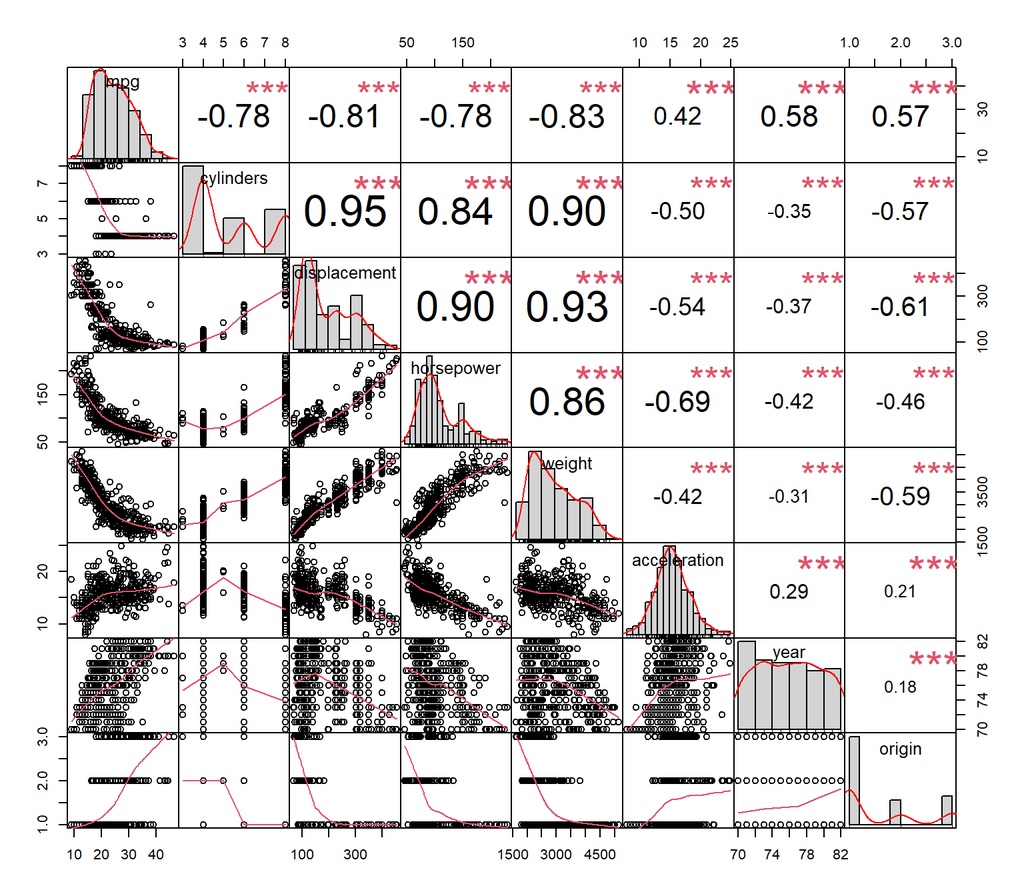

```r
datos = subset(datos, select =c("mpg","cylinders","displacement","horsepower","weight","acceleration","year","origin")) #creamos subconjuntos de variables para ver las correlaciones
chart.Correlation(datos)
```

# 2 - Ejercicio 2

Estime un modelo lineal simple entre el consumo de gasolina, en millas por galón (mpg_i), y el tamaño del motor (o cilindrada) medido en pulgadas cúbicas (displacement_i) y responda qué efecto tiene la potencia del coche en el consumo de gasolina. Estime un segundo modelo lineal simple entre consumo de combustible y el peso del vehículo (weight_i) y explique qué efecto tiene el peso del coche en el consumo de esta muestra de automóviles.

#### mpg~displacement

El coeficiente para la variable displacement representa el cambio en el mpg asociado con un aumento de una unidad en el displacement, manteniendo todas las demás variables constantes. El coeficiente negativo indica que a medida que aumenta el tamaño del motor, disminuye el mpg (consumo de gasolina). Para un aumento de una unidad en displacement, mpg disminuye en 0,06005. También podemos observar que no hay normalidad entre los residuos en este modelo, lo cual puede ser confirmado por la prueba de Lillie.

$$\text{mpg} = 35.12064 - 0.06005 \times \text{displacement}$$

```r
mod1 = lm(mpg ~ displacement, data = datos)
summary(mod1)
```

```
##
## Call:
## lm(formula = mpg ~ displacement, data = datos)
##
## Residuals:
##      Min       1Q   Median       3Q      Max
## -12.9170  -3.0243  -0.5021   2.3512  18.6128
##
## Coefficients:
##              Estimate Std. Error t value Pr(>|t|)
## (Intercept)  35.12064    0.49443   71.03   <2e-16 ***
## displacement -0.06005    0.00224  -26.81   <2e-16 ***
## ---
## Signif. codes:  0 '***' 0.001 '**' 0.01 '*' 0.05 '.' 0.1 ' ' 1
##
## Residual standard error: 4.635 on 390 degrees of freedom
## Multiple R-squared:  0.6482, Adjusted R-squared:  0.6473
## F-statistic: 718.7 on 1 and 390 DF,  p-value: < 2.2e-16
```

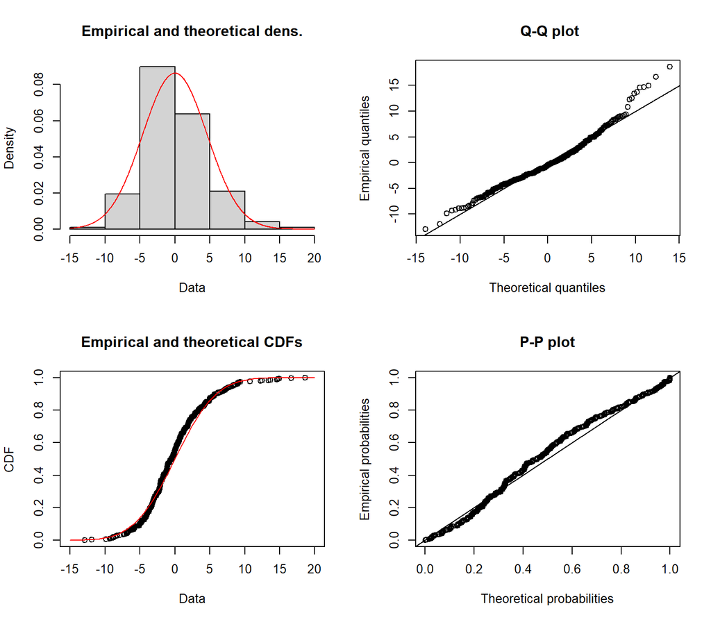

```r
plot(fitdist(mod1$residuals,distr = 'norm'))
```

```r
lillie.test(mod1$residuals)
```

```
##
##  Lilliefors (Kolmogorov-Smirnov) normality test
##
## data:  mod1$residuals
## D = 0.074554, p-value = 1.909e-05
```

#### mpg~weight

Este modelo también presenta resultados similares. El coeficiente negativo de la variable weight indica que al aumentar weight en una unidad, mpg disminuye en un factor de 0,007647.Aquí también podemos observar que no hay normalidad entre los residuos en este modelo, lo que puede ser confirmado por la prueba de Lillie.
$$\text{mpg} = 46.216524 -0.007647 \times \text{weight}$$

```r
mod2 = lm(mpg ~ weight, data = datos)
summary(mod2)
```

```
##
## Call:
## lm(formula = mpg ~ weight, data = datos)
##
## Residuals:
##      Min       1Q   Median       3Q      Max
## -11.9736  -2.7556  -0.3358   2.1379  16.5194
##
## Coefficients:
##              Estimate Std. Error t value Pr(>|t|)
## (Intercept) 46.216524   0.798673   57.87   <2e-16 ***
## weight      -0.007647   0.000258  -29.64   <2e-16 ***
## ---
## Signif. codes:  0 '***' 0.001 '**' 0.01 '*' 0.05 '.' 0.1 ' ' 1
##
## Residual standard error: 4.333 on 390 degrees of freedom
## Multiple R-squared:  0.6926, Adjusted R-squared:  0.6918
## F-statistic: 878.8 on 1 and 390 DF,  p-value: < 2.2e-16
```

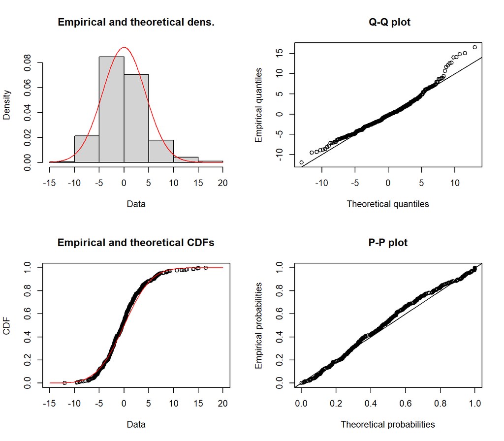

```r
plot(fitdist(mod2$residuals,distr = 'norm'))
```

```r
lillie.test(mod2$residuals)
```

```
##
##  Lilliefors (Kolmogorov-Smirnov) normality test
##
## data:  mod2$residuals
## D = 0.064944, p-value = 0.0004303
```

# 3 - Ejercicio 3

Calcule intervalos de confianza para los parámetros β_0,β_1 en el modelo que relaciona el consumo de gasolina y el tamaño del motor, utilizando el Valor crítico para un α=0.10 (utilice la función qt y consulte su ayuda para obtener el valor crítico)

#### Intervalos de confianza

Obtenemos el intervalo de confianza para β_1 y β_0.

Como vemos, estos valores, a este nivel de confianza, oscilan entre -0,06292703 y -0,05717583 para β_1 y entre 34,48593 y 35,75535 para β_0.

```r
#el valor crítico puede calcularse así utilizando qt()
qt(0.90, mod1$df.residual)
```

```
## [1] 1.283726
```

```r
#intervalos de confianza para β_1(displacement)
c(summary(mod1)$coefficients[2,1]-qt(0.90,mod1$df.residual)*summary(mod1)$coefficients[2,2], summary(mod1)$coefficients[2,1]+qt(0.90,mod1$df.residual)*summary(mod1)$coefficients[2,2])
```

```
## [1] -0.06292703 -0.05717583
```

```r
#intervalos de confianza para β_0
c(summary(mod1)$coefficients[1,1]-qt(0.90,mod1$df.residual)*summary(mod1)$coefficients[1,2], summary(mod1)$coefficients[1,1]+qt(0.90,mod1$df.residual)*summary(mod1)$coefficients[1,2])
```

```
## [1] 34.48593 35.75535
```

# 4 - Ejercicio 4

Cree una base de datos con los siguientes valores de tamaño del motor = 80, 90, 100, 110, 120, y de peso = 1500, 1600, 1700, 1800, 1900 y realice un pronóstico del consumo, incluyendo un intervalo de predicción con un α=0.05.

#### Pronóstico del consumo

Creamos un nuevo conjunto de datos.

```r
ndatos <- data.frame(displacement = c(80, 90, 100, 110, 120),
                       weight = c(1500, 1600, 1700, 1800, 1900))
```

Predecimos el consumo (mpg) basándonos en displacement a partir de nuevos datos.

```r
predict(mod1, newdata = ndatos, interval = "prediction", level = 0.95)
```

```
##        fit      lwr      upr
## 1 30.31652 21.17809 39.45495
## 2 29.71601 20.57990 38.85211
## 3 29.11549 19.98150 38.24949
## 4 28.51498 19.38288 37.64708
## 5 27.91446 18.78405 37.04487
```

Predecimos el consumo (mpg) basándonos en weight a partir de nuevos datos.

```r
predict(mod2, newdata = ndatos, interval = "prediction", level = 0.95)
```

```
##        fit      lwr      upr
## 1 34.74551 26.18340 43.30762
## 2 33.98078 25.42296 42.53860
## 3 33.21604 24.66221 41.76987
## 4 32.45131 23.90117 41.00145
## 5 31.68657 23.13983 40.23332
```

# 5 - Ejercicio 5

Realice una selección de variables en el modelo del punto anterior utilizando el método “backward” (no incluya name en el conjunto de variables explicativas), y realice una estimación utilizando la función lm del que considere mejor modelo. Presente el sumario de resultados de dicha regresión y valore los resultados obtenidos.

#### Utilizando el método “backward”

Aquí se excluye la variable “Name” por razones obvias. Incluyo la variable “origin” como un factor ya que podría ser útil porque los coches de diferentes países pueden tener diferentes valores medios de mpg debido a factores como las regulaciones gubernamentales, las preferencias culturales y los avances tecnológicos. No voy a tratar la variable “year” como un factor ya que tratarlo como una variable categórica con niveles desordenados puede no tener sentido porque los años en el conjunto de datos tienen un orden natural.

```r
X <- model.matrix(mpg ~ cylinders+displacement+horsepower+weight+acceleration+year+as.factor(origin), data = datos)
y <- datos$mpg

backward <- regsubsets(X, y, method = "backward")
```

```
## Reordering variables and trying again:
```

```r
summary(backward)
```

```
## Subset selection object
## 9 Variables  (and intercept)
##                    Forced in Forced out
## cylinders              FALSE      FALSE
## displacement           FALSE      FALSE
## horsepower             FALSE      FALSE
## weight                 FALSE      FALSE
## acceleration           FALSE      FALSE
## year                   FALSE      FALSE
## as.factor(origin)2     FALSE      FALSE
## as.factor(origin)3     FALSE      FALSE
## (Intercept)            FALSE      FALSE
## 1 subsets of each size up to 8
## Selection Algorithm: backward
##          (Intercept) cylinders displacement horsepower weight acceleration year
## 1  ( 1 ) " "         " "       " "          " "        "*"    " "          " "
## 2  ( 1 ) " "         " "       " "          " "        "*"    " "          "*"
## 3  ( 1 ) " "         " "       " "          " "        "*"    " "          "*"
## 4  ( 1 ) " "         " "       " "          " "        "*"    " "          "*"
## 5  ( 1 ) " "         " "       "*"          " "        "*"    " "          "*"
## 6  ( 1 ) " "         " "       "*"          "*"        "*"    " "          "*"
## 7  ( 1 ) " "         "*"       "*"          "*"        "*"    " "          "*"
## 8  ( 1 ) " "         "*"       "*"          "*"        "*"    "*"          "*"
##          as.factor(origin)2 as.factor(origin)3
## 1  ( 1 ) " "                " "
## 2  ( 1 ) " "                " "
## 3  ( 1 ) " "                "*"
## 4  ( 1 ) "*"                "*"
## 5  ( 1 ) "*"                "*"
## 6  ( 1 ) "*"                "*"
## 7  ( 1 ) "*"                "*"
## 8  ( 1 ) "*"                "*"
```

```r
coef(backward, 1:8)
```

```
## [[1]]
##  (Intercept) acceleration
##     4.833250     1.197624
##
## [[2]]
##        (Intercept)       acceleration as.factor(origin)2
##           5.745174           1.101443           3.360002
##
## [[3]]
##        (Intercept)       acceleration as.factor(origin)2        (Intercept)
##           5.745174           1.101443           3.360002           0.000000
##
## [[4]]
##        (Intercept)       acceleration as.factor(origin)2 as.factor(origin)3
##          7.0138041          0.8685449          6.0026919          9.3905888
##        (Intercept)
##          0.0000000
##
## [[5]]
##        (Intercept)         horsepower       acceleration as.factor(origin)2
##         46.0945717         -0.1589370         -0.4762986          2.3111629
## as.factor(origin)3        (Intercept)
##          4.7476412          0.0000000
##
## [[6]]
##        (Intercept)         horsepower             weight       acceleration
##       43.291412395       -0.056431908       -0.004767194       -0.030851316
## as.factor(origin)2 as.factor(origin)3        (Intercept)
##        0.976564854        2.752443985        0.000000000
##
## [[7]]
##        (Intercept)       displacement         horsepower             weight
##       43.390509382        0.002680588       -0.058460710       -0.004954585
##       acceleration as.factor(origin)2 as.factor(origin)3        (Intercept)
##       -0.023451617        1.078763735        2.836564448        0.000000000
##
## [[8]]
##        (Intercept)       displacement         horsepower             weight
##      -19.247520701        0.016435778       -0.015629435       -0.006836797
##       acceleration               year as.factor(origin)2 as.factor(origin)3
##        0.086660226        0.778279498        2.591975377        2.770109977
##        (Intercept)
##        0.000000000
```

Basándonos en los resultados anteriores, seleccionamos las mejores variables y comprobamos sus resultados.

```r
summary(lm(mpg ~ cylinders+displacement+horsepower+weight+acceleration+year+as.factor(origin), data = datos))
```

```
##
## Call:
## lm(formula = mpg ~ cylinders + displacement + horsepower + weight +
##     acceleration + year + as.factor(origin), data = datos)
##
## Residuals:
##     Min      1Q  Median      3Q     Max
## -9.0095 -2.0785 -0.0982  1.9856 13.3608
##
## Coefficients:
##                      Estimate Std. Error t value Pr(>|t|)
## (Intercept)        -1.795e+01  4.677e+00  -3.839 0.000145 ***
## cylinders          -4.897e-01  3.212e-01  -1.524 0.128215
## displacement        2.398e-02  7.653e-03   3.133 0.001863 **
## horsepower         -1.818e-02  1.371e-02  -1.326 0.185488
## weight             -6.710e-03  6.551e-04 -10.243  < 2e-16 ***
## acceleration        7.910e-02  9.822e-02   0.805 0.421101
## year                7.770e-01  5.178e-02  15.005  < 2e-16 ***
## as.factor(origin)2  2.630e+00  5.664e-01   4.643 4.72e-06 ***
## as.factor(origin)3  2.853e+00  5.527e-01   5.162 3.93e-07 ***
## ---
## Signif. codes:  0 '***' 0.001 '**' 0.01 '*' 0.05 '.' 0.1 ' ' 1
##
## Residual standard error: 3.307 on 383 degrees of freedom
## Multiple R-squared:  0.8242, Adjusted R-squared:  0.8205
## F-statistic: 224.5 on 8 and 383 DF,  p-value: < 2.2e-16
```

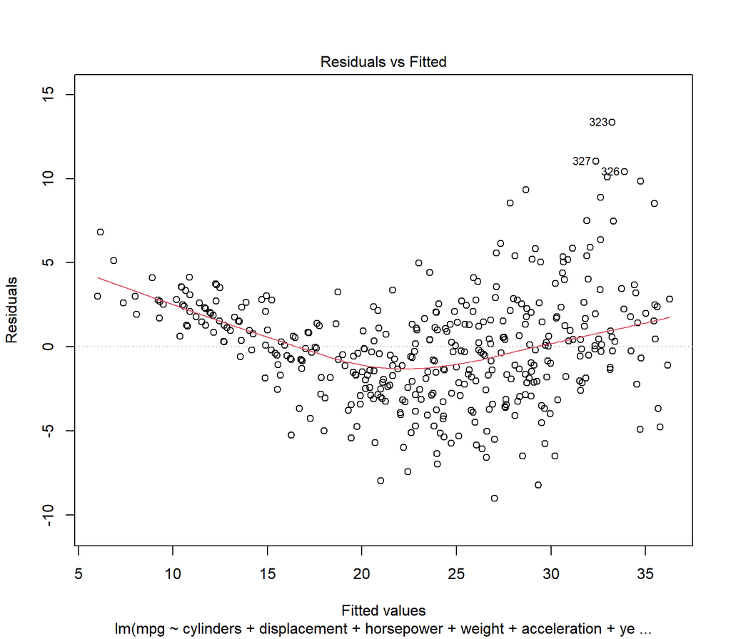

```r
plot((lm(mpg ~ cylinders+displacement+horsepower+weight+acceleration+year+as.factor(origin), data = datos)),1)
```

En el modelo anterior podemos ver que cylinders,horsepower,acceleration no son significativos. También ya que están altamente correlacionados, los eliminamos y observamos el cambio.

```r
summary(lm(mpg ~ weight + year+as.factor(origin)+displacement, data = datos))
```

```
##
## Call:
## lm(formula = mpg ~ weight + year + as.factor(origin) + displacement,
##     data = datos)
##
## Residuals:
##     Min      1Q  Median      3Q     Max
## -9.2633 -2.1572  0.0205  1.8226 13.5061
##
## Coefficients:
##                      Estimate Std. Error t value Pr(>|t|)
## (Intercept)        -1.959e+01  4.064e+00  -4.822 2.05e-06 ***
## weight             -6.820e-03  5.637e-04 -12.099  < 2e-16 ***
## year                7.980e-01  5.081e-02  15.705  < 2e-16 ***
## as.factor(origin)2  2.383e+00  5.606e-01   4.251 2.67e-05 ***
## as.factor(origin)3  2.438e+00  5.309e-01   4.592 5.94e-06 ***
## displacement        9.321e-03  5.001e-03   1.864   0.0631 .
## ---
## Signif. codes:  0 '***' 0.001 '**' 0.01 '*' 0.05 '.' 0.1 ' ' 1
##
## Residual standard error: 3.327 on 386 degrees of freedom
## Multiple R-squared:  0.8206, Adjusted R-squared:  0.8183
## F-statistic: 353.2 on 5 and 386 DF,  p-value: < 2.2e-16
```

Según los resultados, el valor de R-cuadrado no disminuye demasiado. Sólo el displacement no es significativo, por lo que podemos eliminarlo.

```r
summary(lm(mpg ~ weight + year+as.factor(origin), data = datos))
```

```
##
## Call:
## lm(formula = mpg ~ weight + year + as.factor(origin), data = datos)
##
## Residuals:
##     Min      1Q  Median      3Q     Max
## -9.6025 -2.1132 -0.0206  1.7617 13.5261
##
## Coefficients:
##                      Estimate Std. Error t value Pr(>|t|)
## (Intercept)        -1.831e+01  4.017e+00  -4.557 6.96e-06 ***
## weight             -5.887e-03  2.599e-04 -22.647  < 2e-16 ***
## year                7.698e-01  4.867e-02  15.818  < 2e-16 ***
## as.factor(origin)2  1.976e+00  5.180e-01   3.815 0.000158 ***
## as.factor(origin)3  2.215e+00  5.188e-01   4.268 2.48e-05 ***
## ---
## Signif. codes:  0 '***' 0.001 '**' 0.01 '*' 0.05 '.' 0.1 ' ' 1
##
## Residual standard error: 3.337 on 387 degrees of freedom
## Multiple R-squared:  0.819,  Adjusted R-squared:  0.8172
## F-statistic: 437.9 on 4 and 387 DF,  p-value: < 2.2e-16
```

```r
summary(aov(lm(mpg ~ weight + year+as.factor(origin), data = datos)))
```

```
##                    Df Sum Sq Mean Sq F value   Pr(>F)
## weight              1  16498   16498 1481.21  < 2e-16 ***
## year                1   2752    2752  247.11  < 2e-16 ***
## as.factor(origin)   2    259     129   11.61 1.27e-05 ***
## Residuals         387   4310      11
## ---
## Signif. codes:  0 '***' 0.001 '**' 0.01 '*' 0.05 '.' 0.1 ' ' 1
```

Aquí observamos que todas las variables son significativas y el valor R-cuadrado es similar al del modelo anterior. Ahora comprobamos la hipótesis.

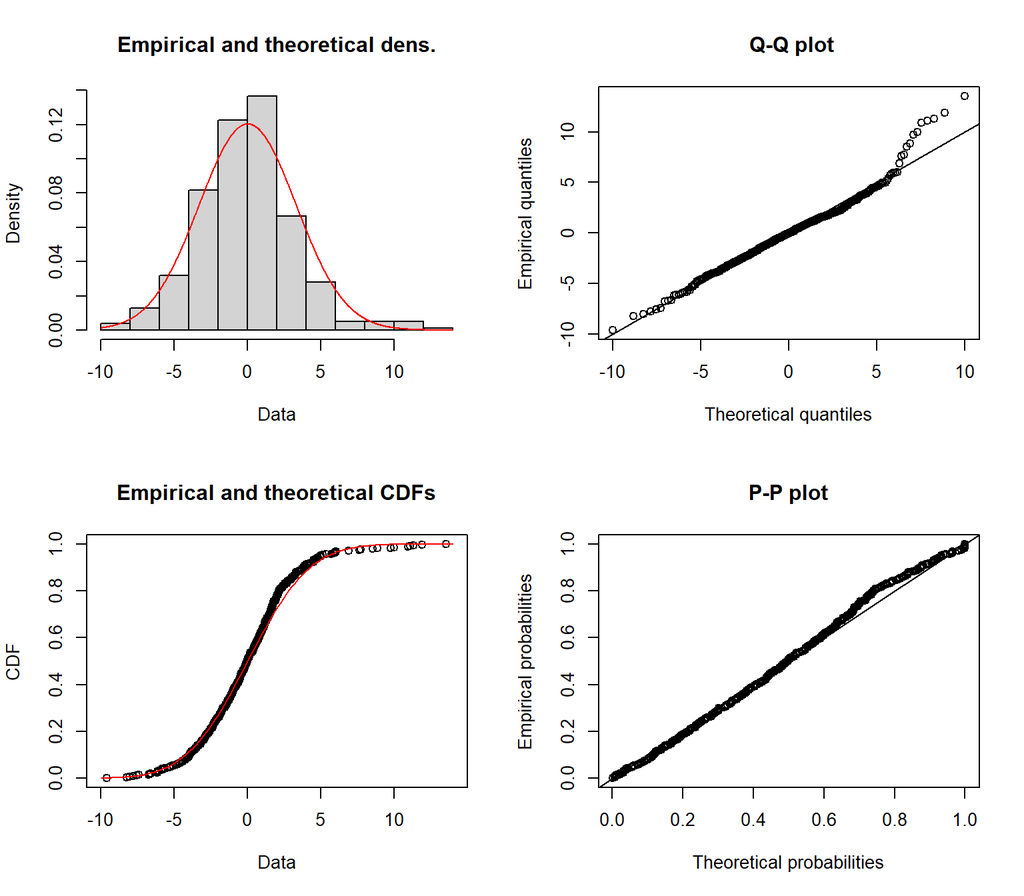

```r
plot(fitdist((lm(mpg ~ weight + year+as.factor(origin), data = datos))$residuals,distr = "norm"))
```

```r
lillie.test((lm(mpg ~ weight + year+as.factor(origin), data = datos))$residuals)
```

```
##
##  Lilliefors (Kolmogorov-Smirnov) normality test
##
## data:  (lm(mpg ~ weight + year + as.factor(origin), data = datos))$residuals
## D = 0.063034, p-value = 0.0007524
```

Comprobamos la normalidad de los residuos y observamos que el QQ-plot, P-P plot y la prueba de Lillie indican que no hay normalidad entre los residuos. Por lo que podemos utilizar la transformación de Boxcox.

#### Boxcox para mpg:

```r
library(EnvStats)
```

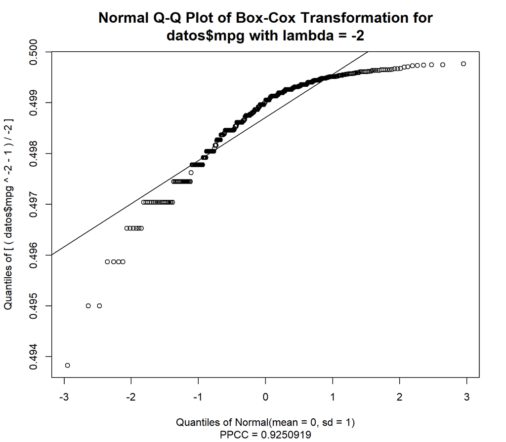

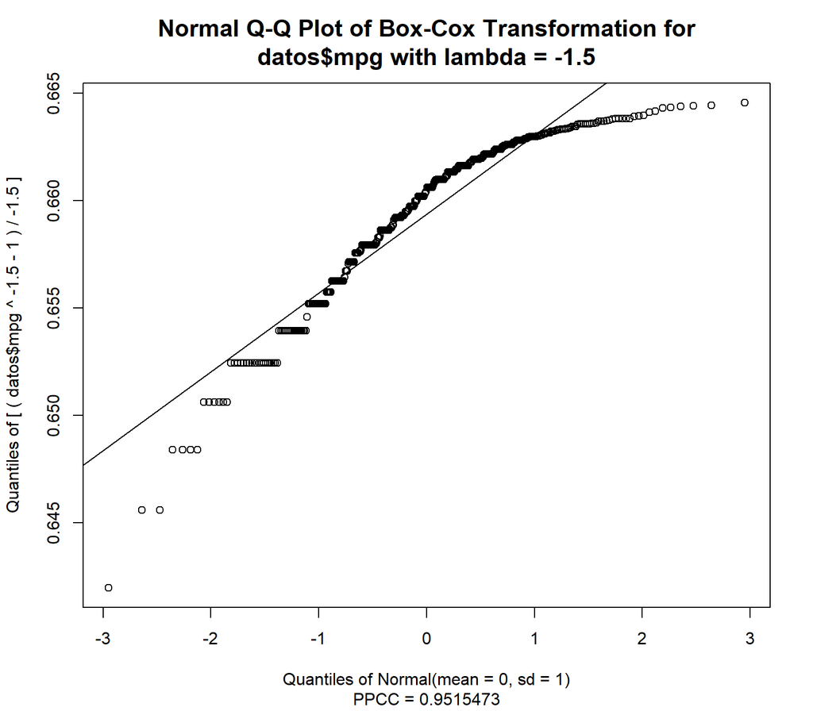

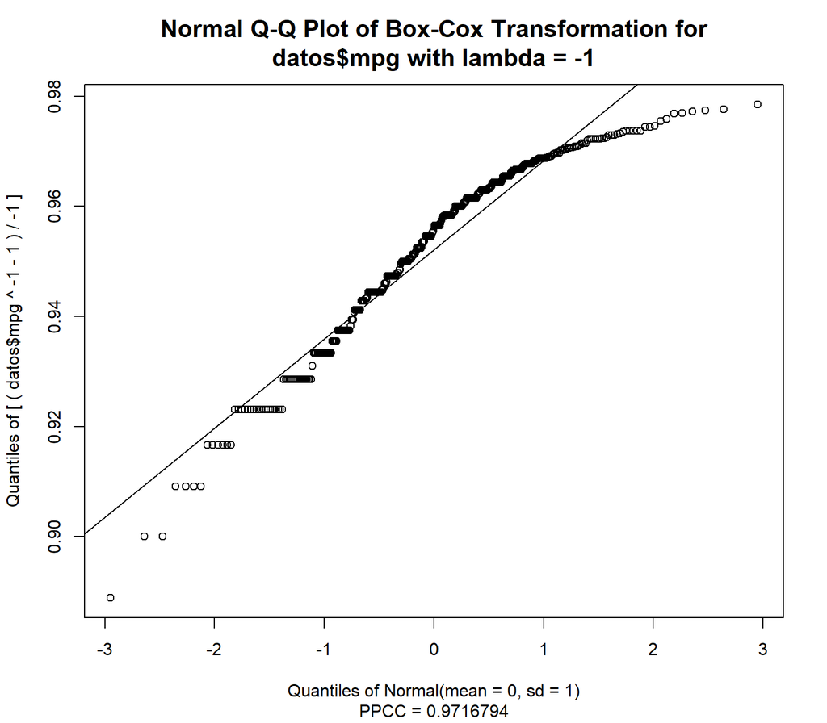

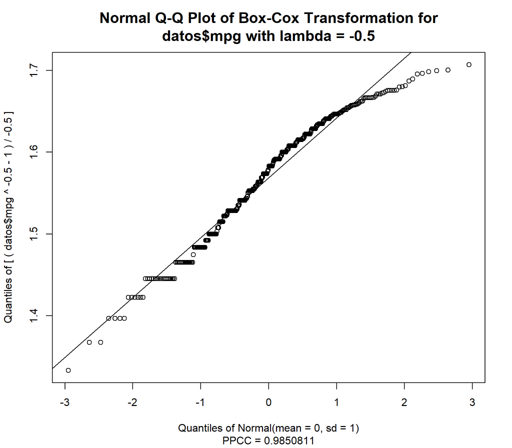

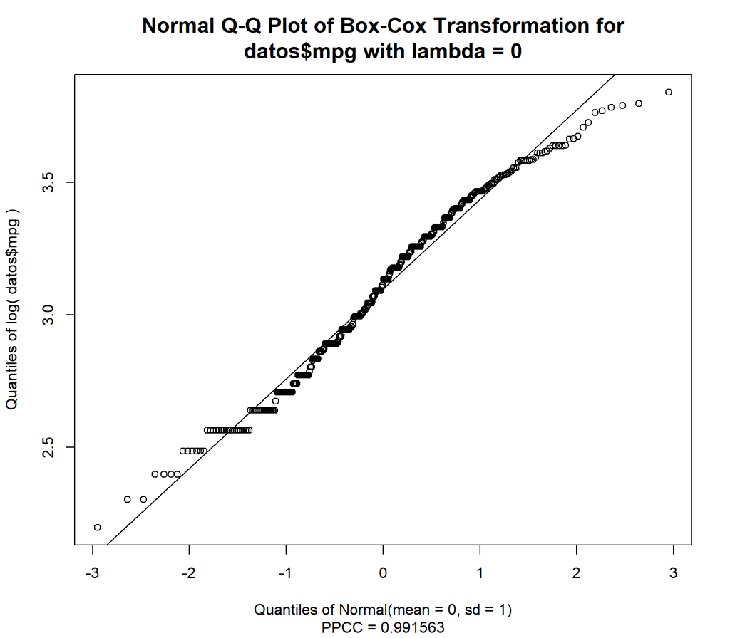

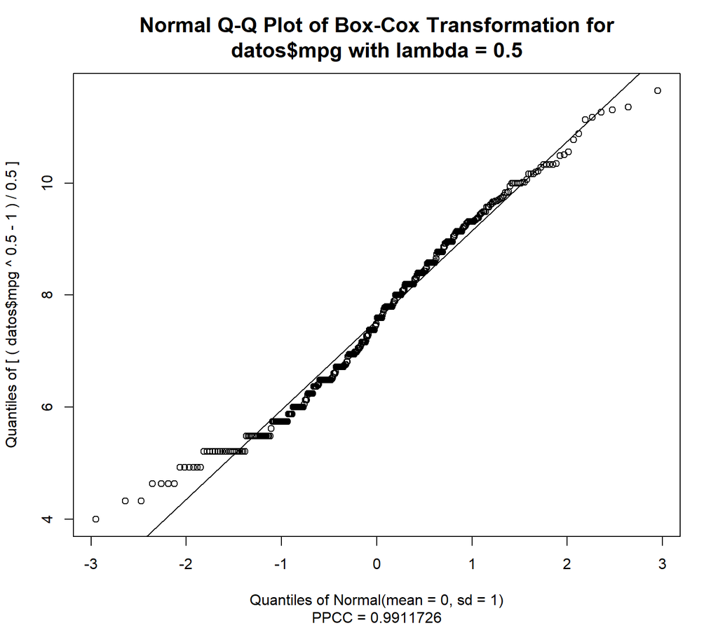

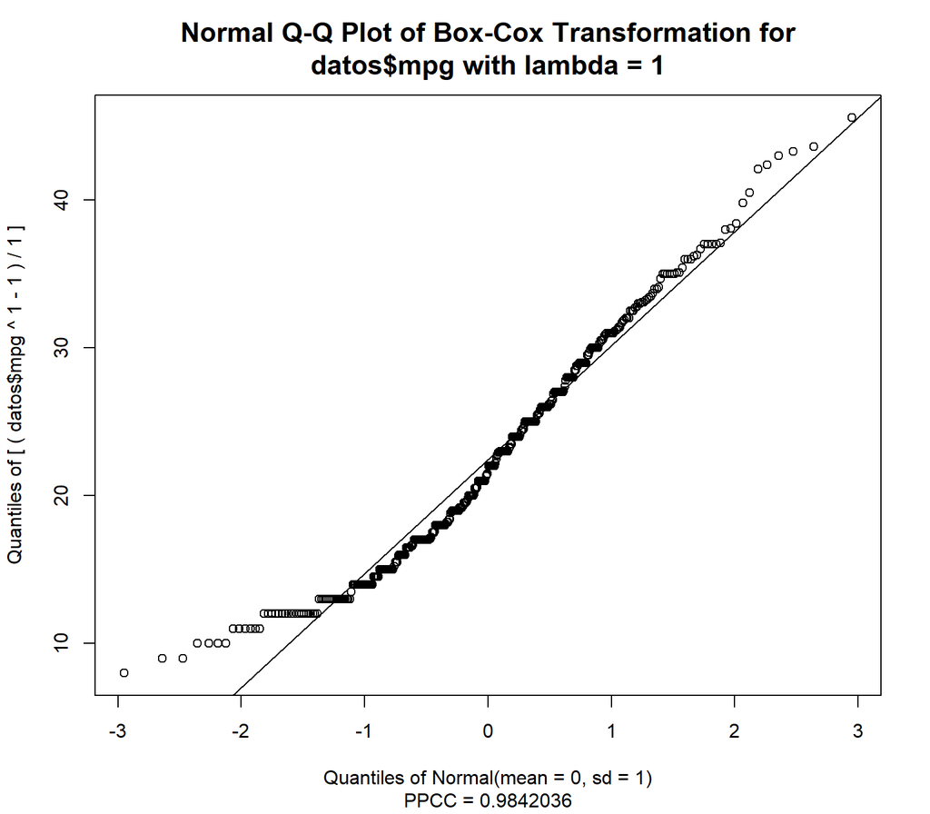

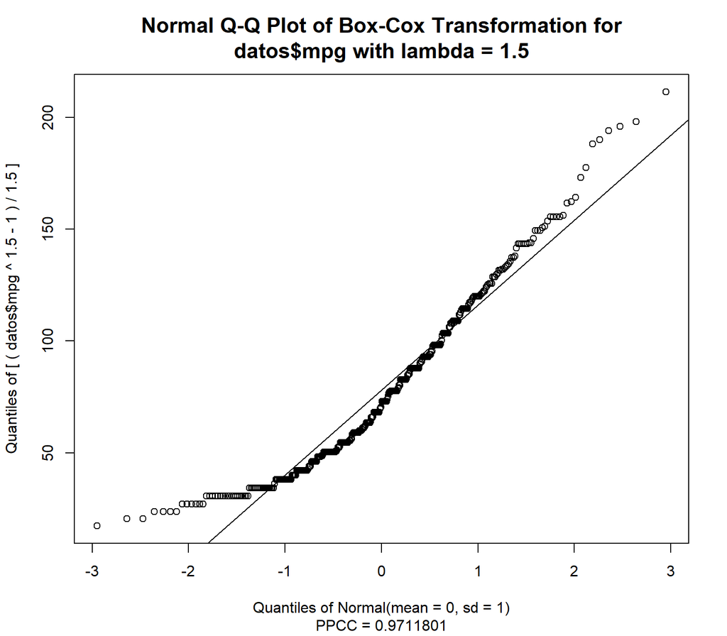

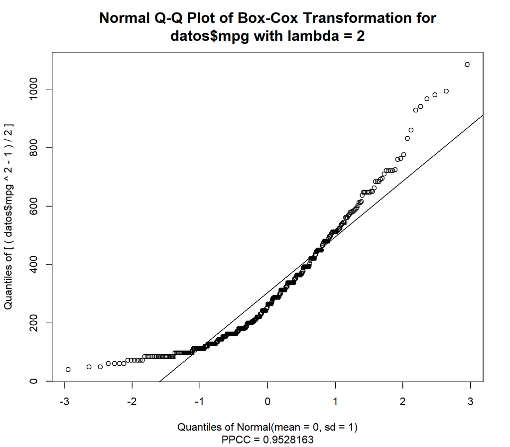

```r
boxcox.list<-boxcox(datos$mpg)
plot(boxcox.list, plot.type="Q-Q Plots")
```

```r
lambda<-boxcox(datos$mpg, optimize=TRUE)$lambda
lambda
```

```
## [1] 0.2203311
```

Como lambda es cercano a 0, podemos tomar logaritmos en la variable.

Aquí usamos log() para mpg. Podemos ver que todas las variables son significativas.También han mejorado el valor R-cuadrado y el estadístico F del modelo.El valor ajustado de R-cuadrado de 0,8748 indica que el modelo explica el 87,48% de la varianza en mpg, lo que representa un ajuste realmente bueno.

Ahora comprobamos la hipótesis

```r
mod3 = lm(log(mpg) ~ weight + year+as.factor(origin), data = datos)
summary(mod3)
```

```
##
## Call:
## lm(formula = log(mpg) ~ weight + year + as.factor(origin), data = datos)
##
## Residuals:
##      Min       1Q   Median       3Q      Max
## -0.42352 -0.07273  0.01168  0.07197  0.38176
##
## Coefficients:
##                      Estimate Std. Error t value Pr(>|t|)
## (Intercept)         1.504e+00  1.448e-01  10.386  < 2e-16 ***
## weight             -2.864e-04  9.370e-06 -30.565  < 2e-16 ***
## year                3.189e-02  1.754e-03  18.180  < 2e-16 ***
## as.factor(origin)2  7.031e-02  1.867e-02   3.766 0.000192 ***
## as.factor(origin)3  5.750e-02  1.870e-02   3.074 0.002259 **
## ---
## Signif. codes:  0 '***' 0.001 '**' 0.01 '*' 0.05 '.' 0.1 ' ' 1
##
## Residual standard error: 0.1203 on 387 degrees of freedom
## Multiple R-squared:  0.8761, Adjusted R-squared:  0.8748
## F-statistic: 684.2 on 4 and 387 DF,  p-value: < 2.2e-16
```

```r
summary(aov(mod3))
```

```
##                    Df Sum Sq Mean Sq  F value   Pr(>F)
## weight              1  34.67   34.67 2395.355  < 2e-16 ***
## year                1   4.70    4.70  324.667  < 2e-16 ***
## as.factor(origin)   2   0.24    0.12    8.452 0.000256 ***
## Residuals         387   5.60    0.01
## ---
## Signif. codes:  0 '***' 0.001 '**' 0.01 '*' 0.05 '.' 0.1 ' ' 1
```

Observamos los gráficos de residuos, y estos nos indican que existe normalidad entre los residuos. Los Q-Q y P-P plot parecen estar alineados con la línea recta. La normalidad en los residuos puede confirmarse mediante la prueba de Lillie.

Cuando representamos gráficamente los residuos podemos observar que están uniformemente distribuidos, lo que demuestra homocedasticidad. Esto puede confirmarse con la salida de gvlma(). También el resultado de la prueba de Levene muestra que se cumple la hipótesis de homogeneidad de varianzas.

Incluso cuando hay correlaciones muy altas entre las diferentes variables del conjunto de datos, el resultado de vif() muestra que la multicolinealidad entre los regresores es baja.

Sin embargo, no se cumplen algunos otros supuestos. Aun así, este modelo parece ajustarse bien.

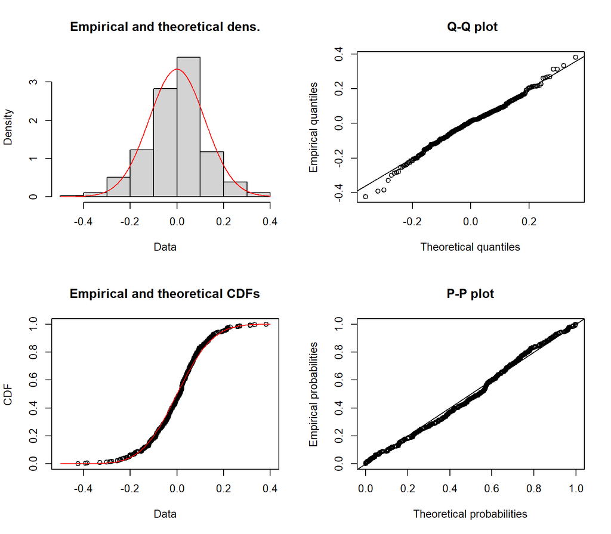

```r
plot(fitdist(mod3$residuals,distr = 'norm')) #normalidad
```

```r
lillie.test(mod3$residuals) #normalidad
```

```
##
##  Lilliefors (Kolmogorov-Smirnov) normality test
##
## data:  mod3$residuals
## D = 0.044968, p-value = 0.05504
```

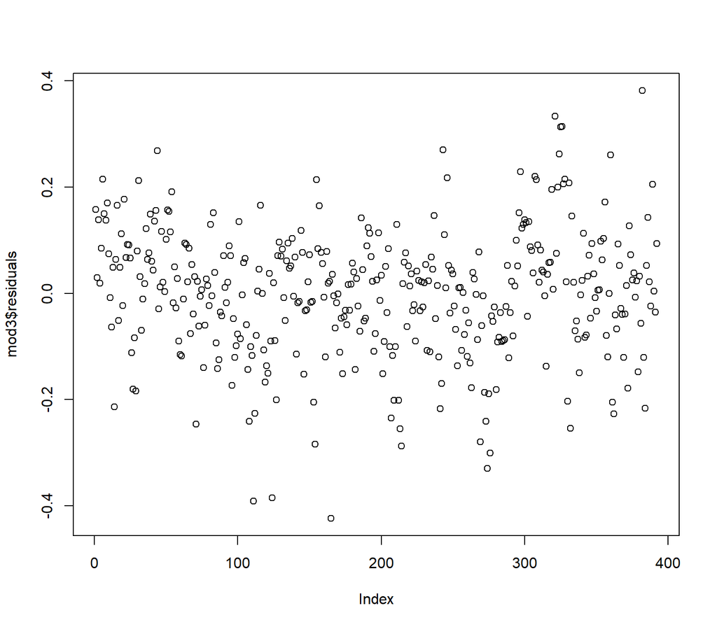

```r
plot(mod3$residuals) #homocedasticidad
```

```r
summary(gvlma(mod3)) #homocedasticidad
```

```
##
## Call:
## lm(formula = log(mpg) ~ weight + year + as.factor(origin), data = datos)
##
## Residuals:
##      Min       1Q   Median       3Q      Max
## -0.42352 -0.07273  0.01168  0.07197  0.38176
##
## Coefficients:
##                      Estimate Std. Error t value Pr(>|t|)
## (Intercept)         1.504e+00  1.448e-01  10.386  < 2e-16 ***
## weight             -2.864e-04  9.370e-06 -30.565  < 2e-16 ***
## year                3.189e-02  1.754e-03  18.180  < 2e-16 ***
## as.factor(origin)2  7.031e-02  1.867e-02   3.766 0.000192 ***
## as.factor(origin)3  5.750e-02  1.870e-02   3.074 0.002259 **
## ---
## Signif. codes:  0 '***' 0.001 '**' 0.01 '*' 0.05 '.' 0.1 ' ' 1
##
## Residual standard error: 0.1203 on 387 degrees of freedom
## Multiple R-squared:  0.8761, Adjusted R-squared:  0.8748
## F-statistic: 684.2 on 4 and 387 DF,  p-value: < 2.2e-16
##
##
## ASSESSMENT OF THE LINEAR MODEL ASSUMPTIONS
## USING THE GLOBAL TEST ON 4 DEGREES-OF-FREEDOM:
## Level of Significance =  0.05
##
## Call:
##  gvlma(x = mod3)
##
##                     Value   p-value                   Decision
## Global Stat        41.844 1.797e-08 Assumptions NOT satisfied!
## Skewness            4.117 4.246e-02 Assumptions NOT satisfied!
## Kurtosis            9.962 1.598e-03 Assumptions NOT satisfied!
## Link Function      25.148 5.310e-07 Assumptions NOT satisfied!
## Heteroscedasticity  2.617 1.057e-01    Assumptions acceptable.
```

```r
leveneTest(datos$mpg,as.factor(datos$origin))
```

```
## Levene's Test for Homogeneity of Variance (center = median)
##        Df F value Pr(>F)
## group   2  0.0861 0.9175
##       389
```

```r
vif(mod3) #multicolinealidad
```

```
##                       GVIF Df GVIF^(1/(2*Df))
## weight            1.711383  1        1.308199
## year              1.128435  1        1.062278
## as.factor(origin) 1.612360  2        1.126848
```

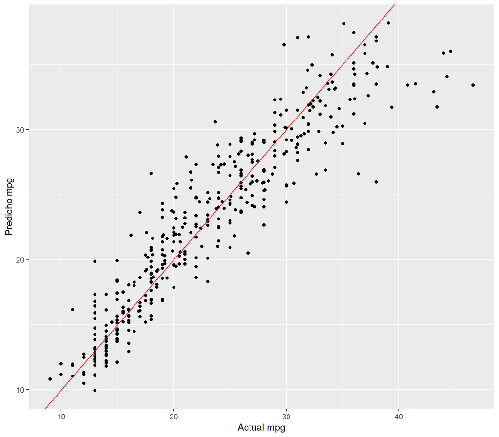

```r
pred <- exp(predict(mod3))

library(ggplot2)
ggplot(data = datos,aes(x = datos$mpg, y = pred)) +
  geom_point() +
  geom_abline(intercept = 0, slope = 1, color = "red") +
  labs(x = "Actual mpg", y = "Predicho mpg")
```

# 6 - Ejercicio 6

Realice un modelo ANOVA explicativo del consumo de gasolina utilizando como factor la cilindrada, obtenga las medias por grupo y pruebe la hipótesis de homocedasticidad. Incluya como covariable los caballos de vapor y comente los resultados obtenidos.

#### ANOVA - La cilindrada como factor

Antes de continuar, como podemos observar que el número de observaciones de los cilindros nivel 3 y 5 es muy bajo, y ya que puede crear problemas en nuestro análisis debido al número muy bajo de observaciones, los eliminaremos de nuestros cálculos para este ejercicio.

```r
table(datos$cylinders)
```

```
##
##   3   4   5   6   8
##   4 199   3  83 103
```

```r
datos_cyl <- subset(datos, cylinders %in% c(4,6,8))
table(datos_cyl$cylinders)
```

```
##
##   4   6   8
## 199  83 103
```

Realizamos el ANOVA y visualizamos las medias de cada grupo mediante una tabla y un boxplot. Podemos ver que el número de cilindros tiene un valor p muy pequeño, lo que indica que es significativo para determinar el consumo (mpg) de un coche. También obtenemos las medias por grupos y observamos que hay diferencia en las medias de los distintos grupos.

```r
datos_cyl$cylinders = as.factor(datos_cyl$cylinders)#convertimos cylinders a factores
ANOVA = aov(mpg~cylinders,data = datos_cyl)
model.tables(ANOVA, type="means")
```

```
## Tables of means
## Grand mean
##
## 23.44545
##
##  cylinders
##          4     6      8
##      29.28 19.97  14.96
## rep 199.00 83.00 103.00
```

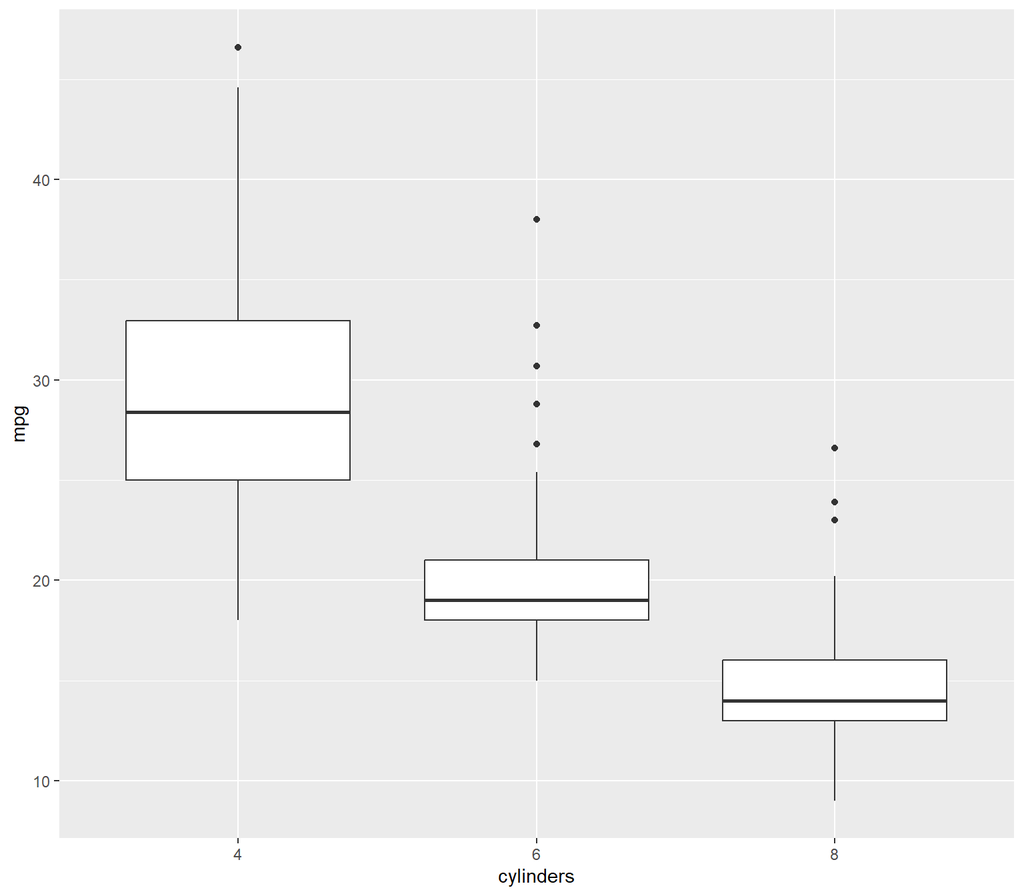

```r
ggplot(datos_cyl, aes(cylinders, mpg)) + geom_boxplot()
```

```r
summary(lm(mpg~cylinders,data = datos_cyl))
```

```
##
## Call:
## lm(formula = mpg ~ cylinders, data = datos_cyl)
##
## Residuals:
##      Min       1Q   Median       3Q      Max
## -11.2839  -2.9631  -0.9631   2.3161  18.0265
##
## Coefficients:
##             Estimate Std. Error t value Pr(>|t|)
## (Intercept)  29.2839     0.3322   88.15   <2e-16 ***
## cylinders6   -9.3104     0.6123  -15.21   <2e-16 ***
## cylinders8  -14.3208     0.5688  -25.18   <2e-16 ***
## ---
## Signif. codes:  0 '***' 0.001 '**' 0.01 '*' 0.05 '.' 0.1 ' ' 1
##
## Residual standard error: 4.686 on 382 degrees of freedom
## Multiple R-squared:  0.6443, Adjusted R-squared:  0.6424
## F-statistic: 345.9 on 2 and 382 DF,  p-value: < 2.2e-16
```

Como podemos observar que el valor de p para todos los factores es inferior a 0,05, podemos concluir que no hay normalidad.

```r
MPG <- split(datos_cyl$mpg, datos_cyl$cylinders)

for (i in 1:length(MPG)){
  MPG.i <- as.vector(MPG[i])
  print(MPG.i)
  print(lillie.test(MPG.i[[1]]))
}
```

```
## $`4`
##   [1] 24.0 27.0 26.0 25.0 24.0 25.0 26.0 27.0 28.0 25.0 22.0 23.0 28.0 30.0 30.0
##  [16] 31.0 35.0 27.0 26.0 24.0 25.0 23.0 20.0 21.0 18.0 22.0 21.0 26.0 22.0 28.0
##  [31] 23.0 28.0 27.0 26.0 20.0 21.0 22.0 19.0 26.0 29.0 24.0 20.0 19.0 24.0 31.0
##  [46] 26.0 32.0 25.0 29.0 26.0 26.0 31.0 32.0 28.0 24.0 26.0 24.0 26.0 31.0 29.0
##  [61] 23.0 23.0 24.0 25.0 24.0 29.0 23.0 23.0 22.0 25.0 33.0 28.0 25.0 25.0 26.0
##  [76] 27.0 29.0 24.5 29.0 33.0 29.5 32.0 28.0 26.5 20.0 19.0 31.5 30.0 36.0 25.5
##  [91] 33.5 29.0 24.5 26.0 25.5 30.5 33.5 30.0 30.5 21.5 43.1 36.1 32.8 39.4 36.1
## [106] 25.1 30.0 27.5 27.2 30.9 21.1 23.2 23.8 23.9 21.6 31.5 29.5 22.3 31.9 34.1
## [121] 35.7 27.4 27.2 34.2 34.5 31.8 37.3 28.4 33.5 41.5 38.1 32.1 37.2 28.0 26.4
## [136] 24.3 34.3 29.8 31.3 37.0 32.2 46.6 27.9 40.8 44.3 43.4 30.0 44.6 33.8 29.8
## [151] 35.0 32.4 27.2 26.6 25.8 30.0 39.1 39.0 35.1 32.3 37.0 37.7 34.1 34.7 34.4
## [166] 29.9 33.0 33.7 32.4 32.9 31.6 28.1 28.0 27.0 34.0 31.0 29.0 27.0 24.0 36.0
## [181] 37.0 31.0 38.0 36.0 36.0 36.0 34.0 38.0 32.0 38.0 26.0 32.0 36.0 27.0 27.0
## [196] 44.0 32.0 28.0 31.0
##
##
##  Lilliefors (Kolmogorov-Smirnov) normality test
##
## data:  MPG.i[[1]]
## D = 0.082025, p-value = 0.002392
##
## $`6`
##  [1] 22.0 18.0 21.0 21.0 19.0 16.0 17.0 19.0 18.0 18.0 19.0 18.0 18.0 16.0 18.0
## [16] 18.0 23.0 18.0 21.0 20.0 20.0 19.0 15.0 16.0 16.0 18.0 19.0 18.0 15.0 15.0
## [31] 17.0 16.0 15.0 18.0 21.0 20.0 18.0 19.0 22.0 22.0 24.0 22.5 20.0 18.0 18.5
## [46] 17.5 19.0 16.5 17.5 20.5 19.0 18.5 22.0 19.2 20.5 20.2 20.5 19.4 20.6 20.8
## [61] 18.6 18.1 17.7 17.0 16.2 21.5 19.8 20.2 20.6 28.8 26.8 19.1 32.7 23.5 30.7
## [76] 25.4 24.2 22.4 20.2 17.6 25.0 38.0 22.0
##
##
##  Lilliefors (Kolmogorov-Smirnov) normality test
##
## data:  MPG.i[[1]]
## D = 0.1654, p-value = 7.06e-06
##
## $`8`
##   [1] 18.0 15.0 18.0 16.0 17.0 15.0 14.0 14.0 14.0 15.0 15.0 14.0 15.0 14.0 10.0
##  [16] 10.0 11.0  9.0 14.0 14.0 14.0 14.0 12.0 13.0 13.0 13.0 14.0 15.0 14.0 17.0
##  [31] 11.0 13.0 12.0 13.0 15.0 13.0 13.0 14.0 13.0 14.0 13.0 14.0 15.0 12.0 13.0
##  [46] 13.0 14.0 13.0 12.0 13.0 11.0 12.0 13.0 12.0 15.0 16.0 15.0 11.0 16.0 13.0
##  [61] 14.0 14.0 14.0 16.0 15.0 16.0 14.0 20.0 13.0 17.5 16.0 15.5 14.5 13.0 16.5
##  [76] 13.0 13.0 13.0 17.5 17.0 15.5 15.0 16.0 15.5 15.5 16.0 19.9 19.4 20.2 19.2
##  [91] 18.1 17.5 17.0 17.6 16.5 18.2 16.9 15.5 19.2 18.5 23.0 23.9 26.6
##
##
##  Lilliefors (Kolmogorov-Smirnov) normality test
##
## data:  MPG.i[[1]]
## D = 0.13776, p-value = 5.309e-05
```

Comprobamos la hipótesis de homocedasticidad. Observamos que el Q-Q plot y el P-P plot de los residuos se desvían de la línea diagonal, lo que indica falta de normalidad. El resultado de la prueba de levene indica que el valor p es inferior a 0,001, lo que proporciona pruebas concluyentes contra la hipótesis nula de varianzas iguales. Por lo tanto, podemos concluir que existe una heteroscedasticidad significativa.

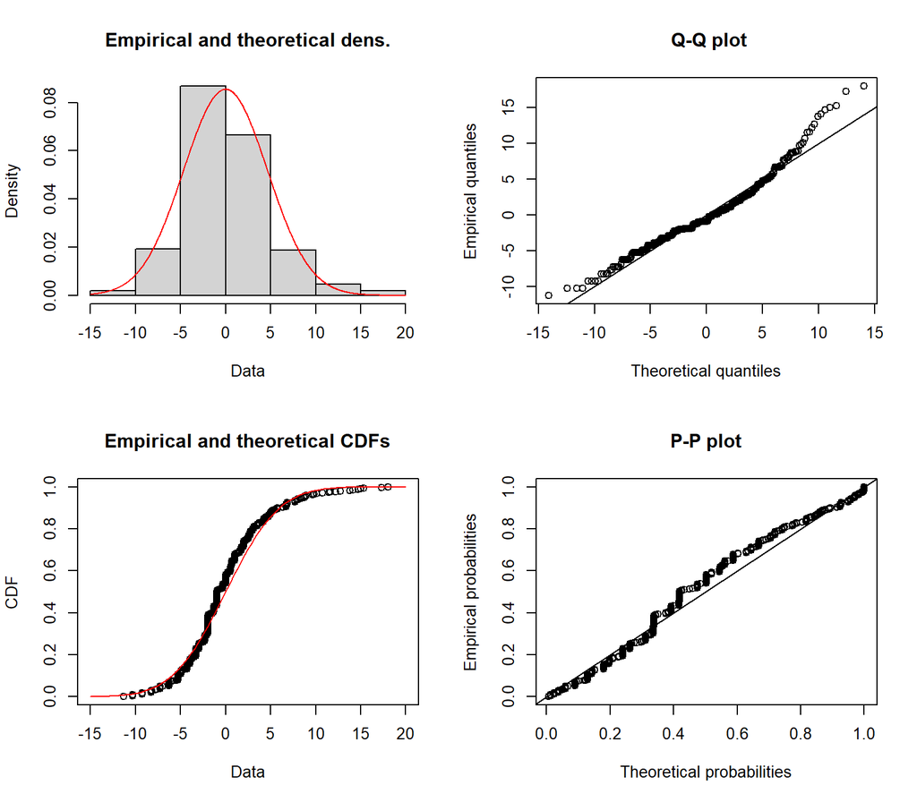

```r
plot(fitdist(lm(mpg~cylinders,data = datos_cyl)$residuals,distr = 'norm'))
```

```r
leveneTest(datos_cyl$mpg,datos_cyl$cylinders, center = mean)
```

```
## Levene's Test for Homogeneity of Variance (center = mean)
##        Df F value    Pr(>F)
## group   2  30.526 5.028e-13 ***
##       382
## ---
## Signif. codes:  0 '***' 0.001 '**' 0.01 '*' 0.05 '.' 0.1 ' ' 1
```

#### ANCOVA - covariable los caballos de vapor

Ahora incluimos “horsepower” como covariable.

Los resultados muestran que tanto el número de “cylinders” como el “horsepower” tienen cierta importancia a la hora de determinar el consumo(mpg) de un coche.

También observamos que aumenta el valor R-cuadrado del modelo en comparación con el modelo anterior. Aún así, este modelo no es bueno en la determinación de mpg ya que todavía tiene falta de normalidad y tiene heteroscedasticidad grave como puede confirmarse por diferentes gráficos de sus residuos y por la prueba de Lillie.

```r
mod4 = lm(mpg ~ cylinders + horsepower, data = datos_cyl)
anova(mod4)
```

```
## Analysis of Variance Table
##
## Response: mpg
##             Df  Sum Sq Mean Sq F value    Pr(>F)
## cylinders    2 15194.8  7597.4 418.287 < 2.2e-16 ***
## horsepower   1  1469.2  1469.2  80.888 < 2.2e-16 ***
## Residuals  381  6920.2    18.2
## ---
## Signif. codes:  0 '***' 0.001 '**' 0.01 '*' 0.05 '.' 0.1 ' ' 1
```

```r
summary(mod4)
```

```
##
## Call:
## lm(formula = mpg ~ cylinders + horsepower, data = datos_cyl)
##
## Residuals:
##     Min      1Q  Median      3Q     Max
## -9.5984 -2.6903 -0.6069  1.8793 16.3424
##
## Coefficients:
##             Estimate Std. Error t value Pr(>|t|)
## (Intercept) 37.27085    0.93803  39.733  < 2e-16 ***
## cylinders6  -6.94086    0.61605 -11.267  < 2e-16 ***
## cylinders8  -6.15655    1.04482  -5.892 8.38e-09 ***
## horsepower  -0.10203    0.01134  -8.994  < 2e-16 ***
## ---
## Signif. codes:  0 '***' 0.001 '**' 0.01 '*' 0.05 '.' 0.1 ' ' 1
##
## Residual standard error: 4.262 on 381 degrees of freedom
## Multiple R-squared:  0.7066, Adjusted R-squared:  0.7043
## F-statistic: 305.8 on 3 and 381 DF,  p-value: < 2.2e-16
```

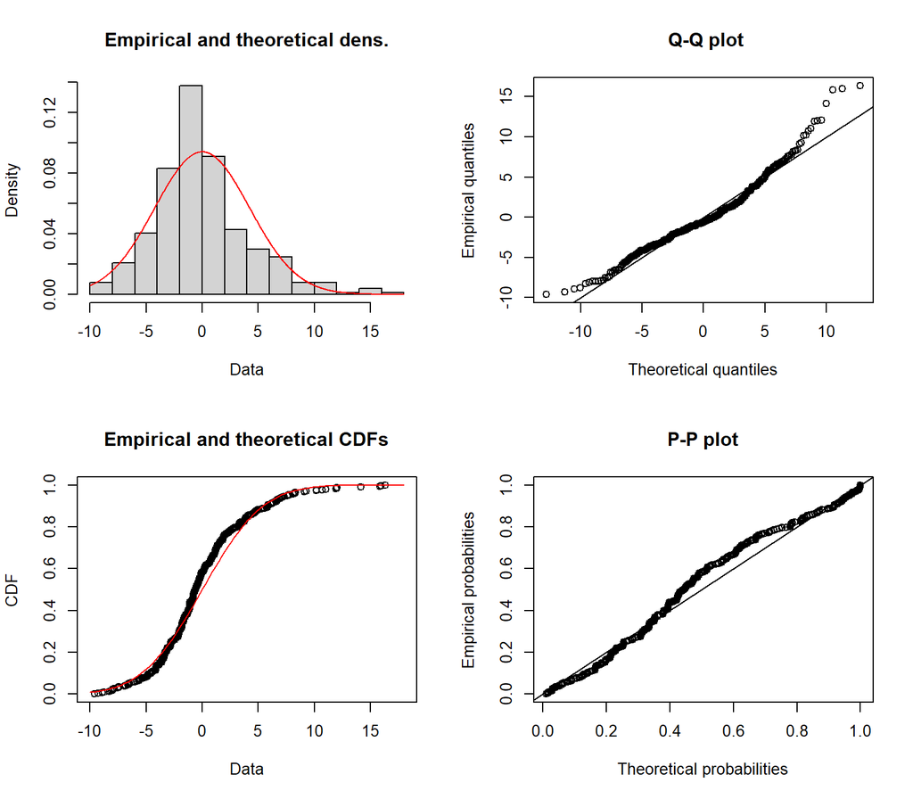

```r
plot(fitdist(mod4$residuals,distr = 'norm'))
```

```r
lillie.test(mod4$residuals)
```

```
##
##  Lilliefors (Kolmogorov-Smirnov) normality test
##
## data:  mod4$residuals
## D = 0.089238, p-value = 8.585e-08
```

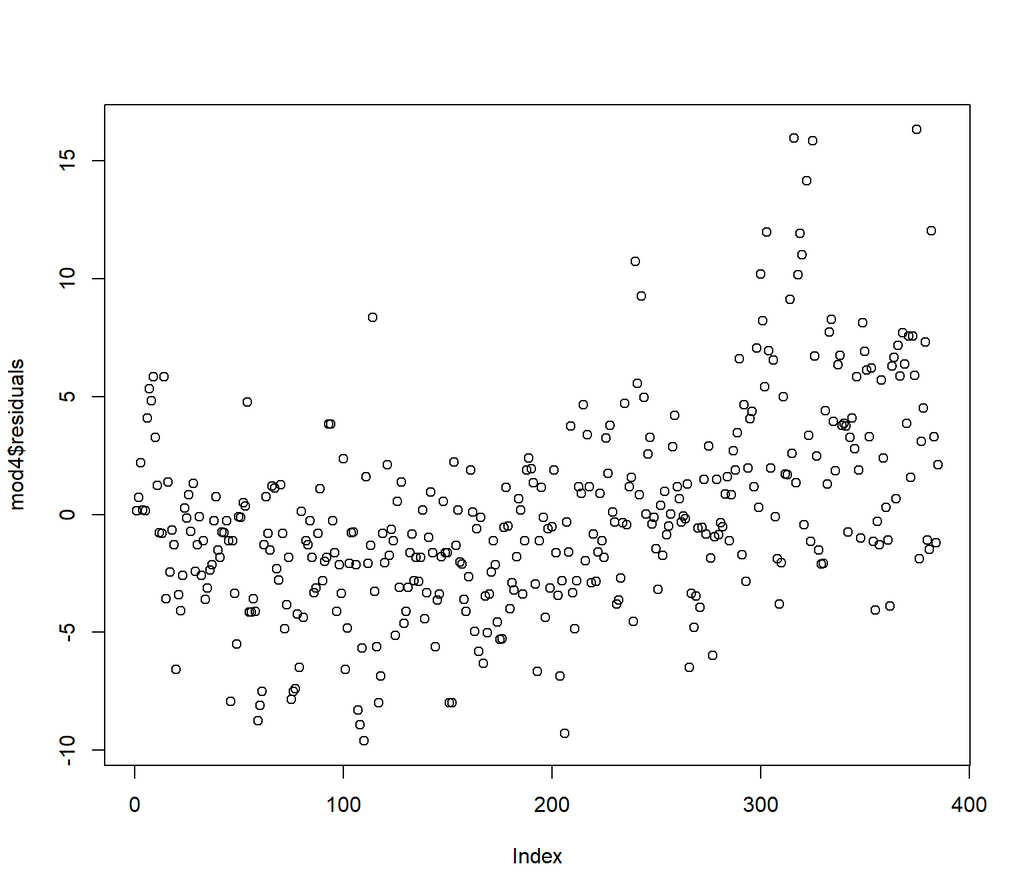

```r
plot(mod4$residuals)
```

# 7 - Ejercicio 7

Estime un modelo lineal múltiple entre el consumo de gasolina, en millas por galón (mpg_i), el tamaño del motor medido en pulgadas cúbicas (displacement_i) y el peso del vehiculo (weight_i) ¿encuentra algún problema en el planteamiento de esta regresión?, si es asi resuélvalo y analice los resultados obtenidos.

#### mpg ~ displacement + weight

Tomamos displacement y weight como predictores para predecir mpg. En este modelo vemos que displacement y weight son significativos, pero los gráficos de los residuos y la prueba de Lillie muestran que no hay normalidad entre los residuos, lo que podría deberse a la alta correlación entre los regresores. Esto se confirma por vif(). Existe una correlación de 0,932 entre displacement y weight lo cual es muy alta. Como la forma más común de resolver esto es eliminar uno de los regresores altamente correlacionados, pero en este caso sólo hay dos regresores y no parece una buena idea eliminar alguno de los dos. Por lo tanto, vamos a considerar hacer ajuste Ridge para resolver el problema de la multicolinealidad.

```r
mod5 <- lm(mpg ~ displacement + weight, data = datos)
summary(mod5)
```

```
##
## Call:
## lm(formula = mpg ~ displacement + weight, data = datos)
##
## Residuals:
##     Min      1Q  Median      3Q     Max
## -12.407  -2.928  -0.357   2.320  16.376
##
## Coefficients:
##                Estimate Std. Error t value Pr(>|t|)
## (Intercept)  43.7776194  1.1630993  37.639  < 2e-16 ***
## displacement -0.0164971  0.0057653  -2.861  0.00444 **
## weight       -0.0057511  0.0007103  -8.097 7.31e-15 ***
## ---
## Signif. codes:  0 '***' 0.001 '**' 0.01 '*' 0.05 '.' 0.1 ' ' 1
##
## Residual standard error: 4.293 on 389 degrees of freedom
## Multiple R-squared:  0.699,  Adjusted R-squared:  0.6974
## F-statistic: 451.6 on 2 and 389 DF,  p-value: < 2.2e-16
```

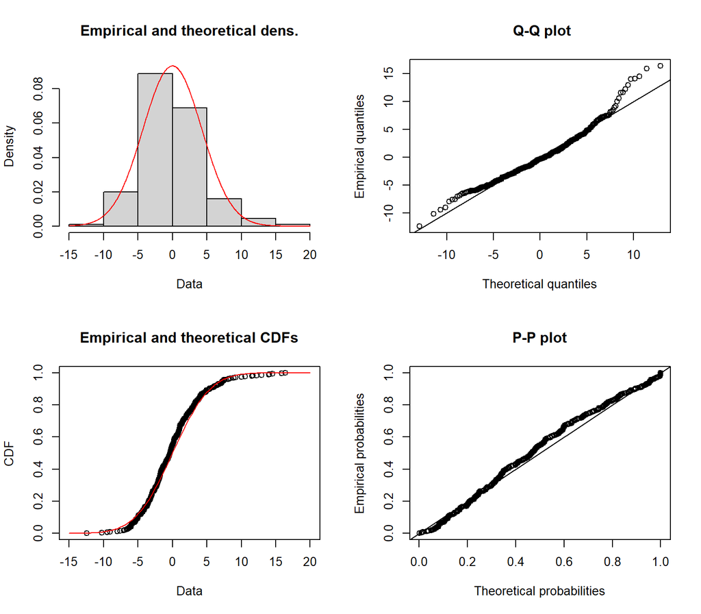

```r
plot(fitdist(mod5$residuals,distr = 'norm'))
```

```r
lillie.test(mod5$residuals)
```

```
##
##  Lilliefors (Kolmogorov-Smirnov) normality test
##
## data:  mod5$residuals
## D = 0.071105, p-value = 6.192e-05
```

```r
vif(mod5)
```

```
## displacement       weight
##     7.720729     7.720729
```

```r
cor(datos$displacement,datos$weight)
```

```
## [1] 0.9329944
```

#### Regresión Ridge

Realización del ajuste Ridge

```r
x <- model.matrix(mpg~displacement+weight, data =datos)[, -1]
head(x)
```

```
##   displacement weight
## 1          307   3504
## 2          350   3693
## 3          318   3436
## 4          304   3433
## 5          302   3449
## 6          429   4341
```

```r
y <- datos$mpg
```

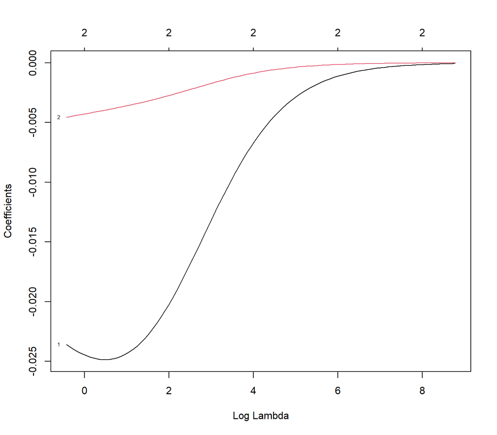

```r
modeloRidge <- glmnet(x,y,alpha=0)
plot(modeloRidge,xvar="lambda",label=TRUE)
```

Buscamos mejor lambda

```r
set.seed(1)
out=cv.glmnet(x,y,alpha=0)
mejorlambda=out$lambda.min
mejorlambda
```

```
## [1] 0.6487382
```

```r
mod6 <- glmnet(x,y,alpha=0, lambda=mejorlambda)
coef(mod6)
```

```
## 3 x 1 sparse Matrix of class "dgCMatrix"
##                        s0
## (Intercept)  41.598768911
## displacement -0.023598893
## weight       -0.004555687
```

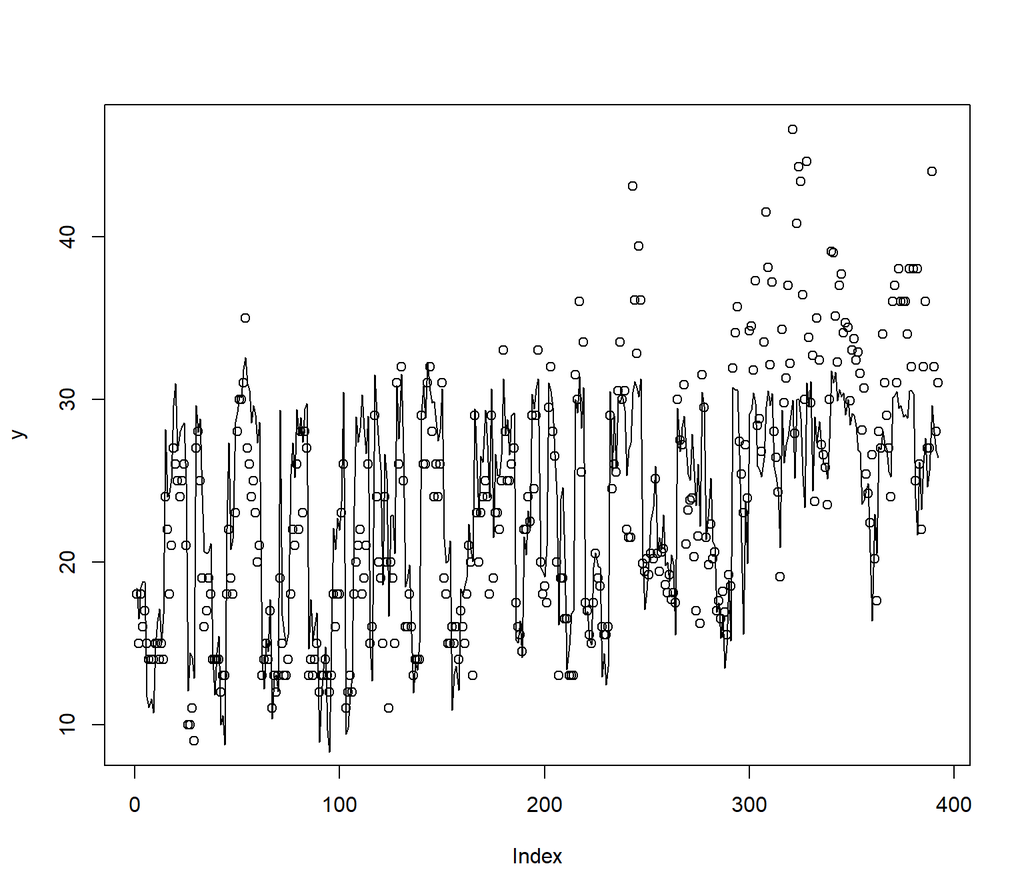

```r
predichos <- predict.glmnet(mod6, x, type = "response")
plot(y)
lines(predichos)
```

```r
rmse(predichos, datos$mpg)
```

```
## [1] 4.297255
```

# 8 - Ejercicio 8

Con el mejor modelo explicativo del consumo de gasolina (millas/galón) de los vehículos, realice una estimación robusta, represéntela gráficamente y comente los resultados.

Considerando todos los modelos que hemos hecho hasta ahora para predecir el consumo de un coche (mpg), algunos modelos tienen un solo regresor que yo no consideraría apropiado para usar ya que tenemos más variables en nuestro conjunto de datos que son significativos en la predicción de “mpg”. El modelo que desarrollamos anteriormente (mod6), incluso después de realizar el ajuste de Ridge, no lo consideraría como el mejor para predecir el mpg debido a la alta correlación entre los regresores y también podría haber un problema de sobreajuste (overfitting). El modelo que realizamos por el método “backward” (mod3) parece dar el mejor resultado basado en sus parámetros. Por tanto, utilizaremos las variables de mod3.

#### Regresión robusta

Hacemos estimaciones robustas

Si observamos el diagrama de influencias, parece que hay pocas observaciones influyentes.

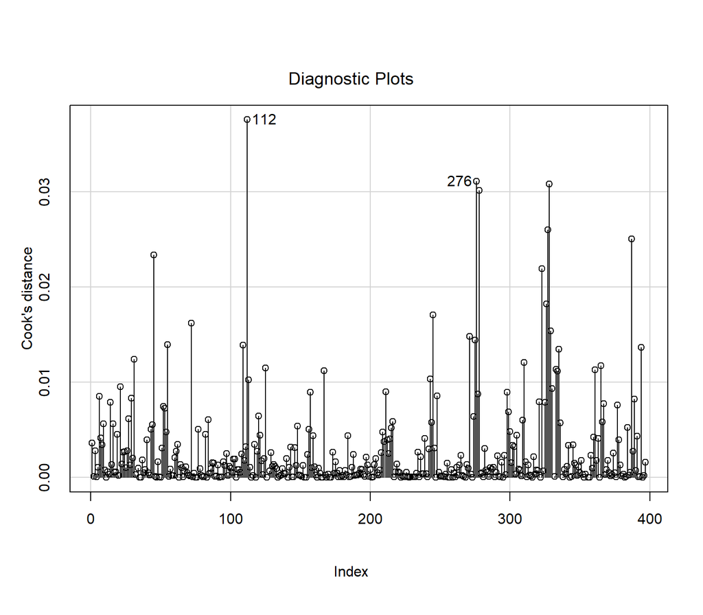

```r
influenceIndexPlot(mod3, vars="Cook")
```

```r
summary(influence.measures(mod3))
```

```
## Potentially influential observations of
##   lm(formula = log(mpg) ~ weight + year + as.factor(origin), data = datos) :
##
##     dfb.1_ dfb.wght dfb.year dfb.a.()2 dfb.a.()3 dffit   cov.r   cook.d hat
## 20  -0.02   0.01     0.02    -0.01      0.00     -0.03    1.04_*  0.00   0.03
## 45   0.01   0.27    -0.07     0.07      0.11      0.34_*  0.97    0.02   0.02
## 112 -0.22   0.09     0.22     0.04     -0.26     -0.44_*  0.90_*  0.04   0.02
## 125 -0.10  -0.04     0.10     0.07      0.04     -0.24    0.89_*  0.01   0.01
## 156 -0.05   0.05     0.03     0.08      0.08     -0.16    0.95_*  0.01   0.00
## 167 -0.07   0.07     0.05     0.12      0.12     -0.24    0.86_*  0.01   0.00
## 215  0.04  -0.09    -0.04     0.02      0.01     -0.16    0.96_*  0.01   0.01
## 216  0.04  -0.08    -0.03     0.03      0.03     -0.17    0.94_*  0.01   0.01
## 271  0.04  -0.06    -0.03    -0.03     -0.22     -0.27    0.96_*  0.01   0.01
## 276  0.17  -0.18    -0.14    -0.35     -0.08     -0.40_*  0.94_*  0.03   0.02
## 278  0.18  -0.22    -0.14    -0.35     -0.10     -0.39_*  0.95_*  0.03   0.02
## 323 -0.09   0.00     0.10     0.00      0.22      0.33    0.93_*  0.02   0.01
## 327 -0.15   0.03     0.16     0.26     -0.01      0.36_*  0.94_*  0.03   0.02
## 328 -0.22   0.15     0.20     0.33      0.05      0.40_*  0.95_*  0.03   0.02
## 387 -0.24  -0.01     0.28    -0.09     -0.14      0.36_*  0.90_*  0.03   0.01
```

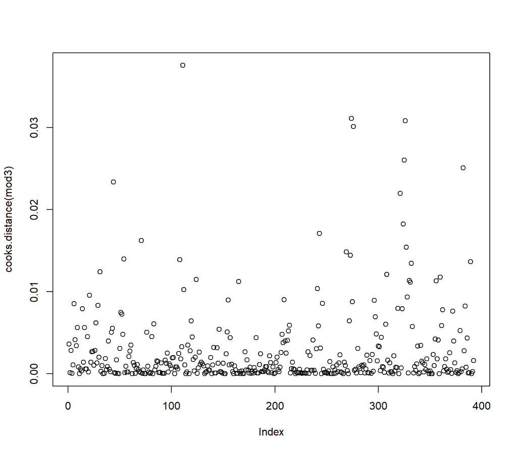

```r
plot(cooks.distance(mod3))
```

#### Estimador Huber

Realizamos una regresión robusta utilizando el método de Huber. Después comprobamos la normalidad.

```r
mod7 = rlm(log(mpg)~weight+year+as.factor(origin),data = datos)
summary(mod7)
```

```
##
## Call: rlm(formula = log(mpg) ~ weight + year + as.factor(origin), data = datos)
## Residuals:
##       Min        1Q    Median        3Q       Max
## -0.428747 -0.072537  0.007751  0.065390  0.387269
##
## Coefficients:
##                    Value    Std. Error t value
## (Intercept)          1.6280   0.1367    11.9053
## weight              -0.0003   0.0000   -32.4536
## year                 0.0303   0.0017    18.3144
## as.factor(origin)2   0.0590   0.0176     3.3457
## as.factor(origin)3   0.0604   0.0177     3.4186
##
## Residual standard error: 0.1041 on 387 degrees of freedom
```

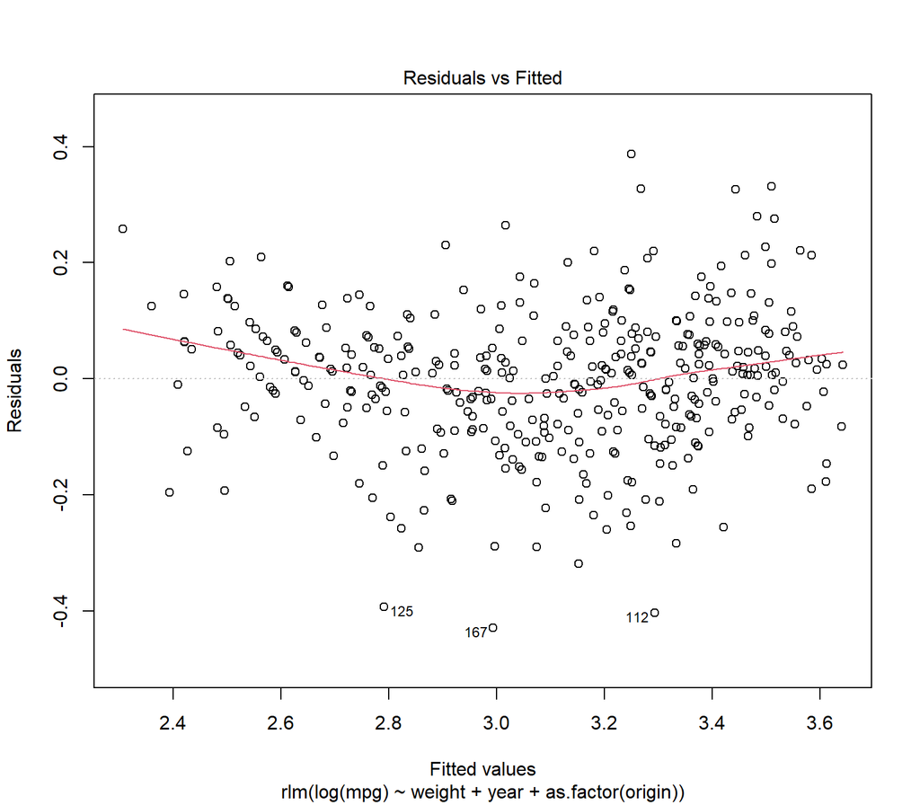

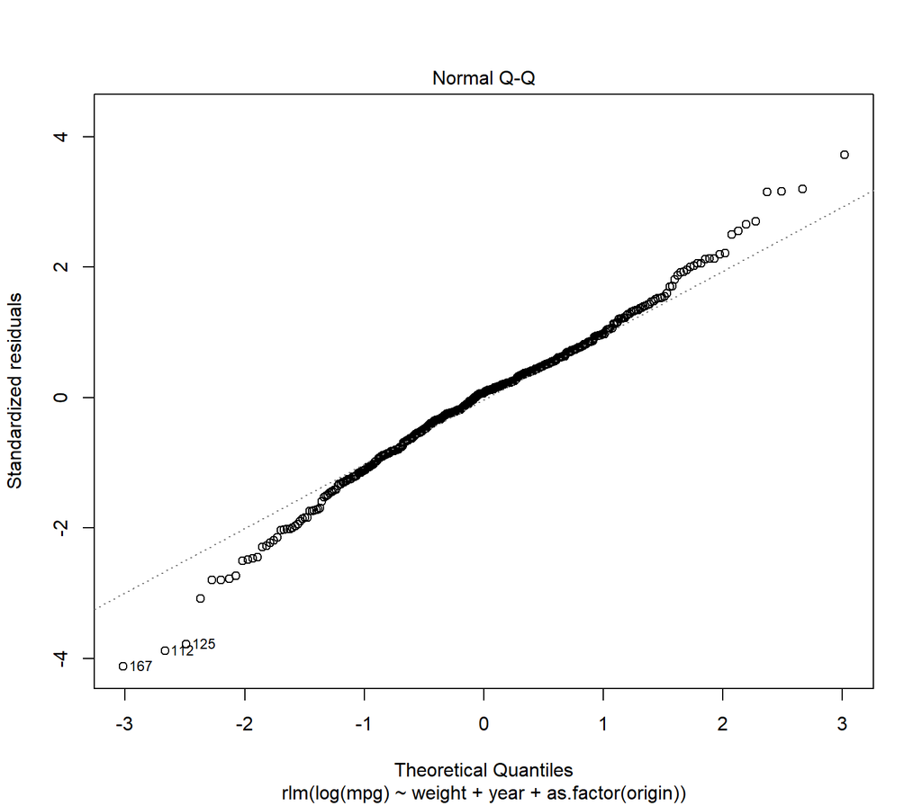

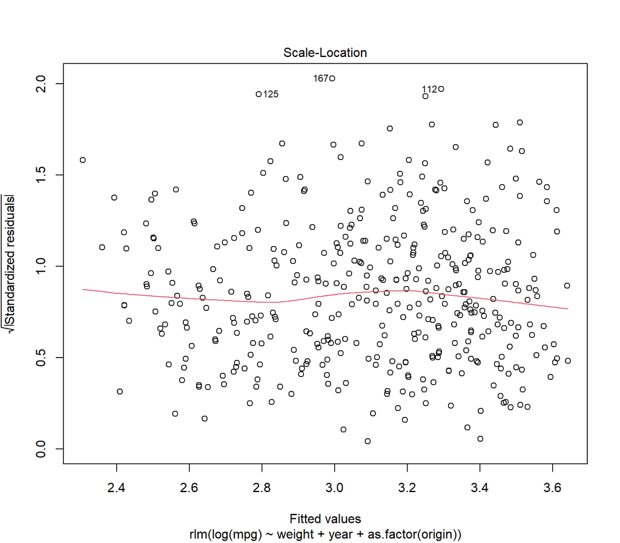

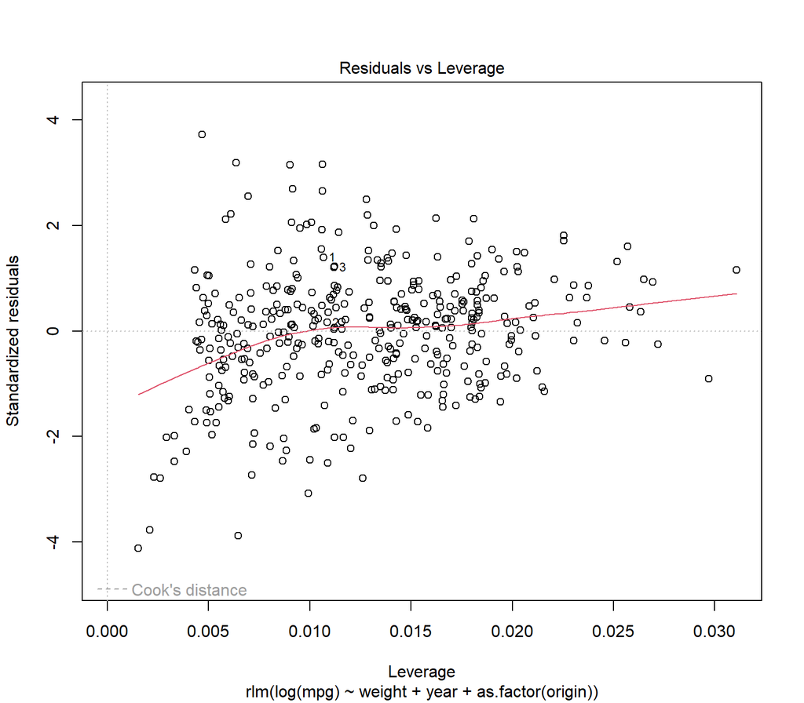

```r
plot(mod7)
```

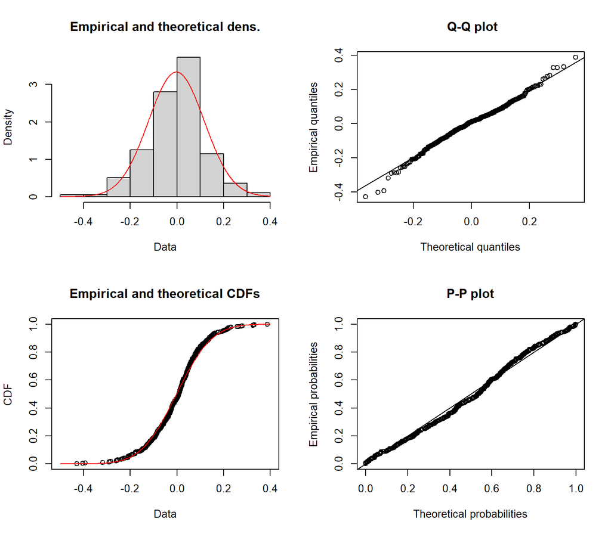

```r
plot(fitdist(mod7$residuals,distr = 'norm'))
```

```r
lillie.test(mod7$residuals)
```

```
##
##  Lilliefors (Kolmogorov-Smirnov) normality test
##
## data:  mod7$residuals
## D = 0.048844, p-value = 0.02549
```